# Projet Analyse de données

# 1 Importation des librairies et des données

On importe les librairies dont on aura besoin tout au long du projet.

Importons les données sous un le format DataFrame.

```r
data = read.csv("./data/Data-projetmodIA-2324.csv")
data = as.data.frame(data)
```

# 2 Préparation des données

Jetons un premier cous d’œil à notre jeu de données.

```r
str(data)
```

```
## 'data.frame':    984 obs. of  36 variables:
##  $ code_epci           : int  200006930 200017341 200022986 200023620 200023737 200027183 200030435 200034023 200034031 200034049 ...
##  $ lib_epci            : chr  "CC du Haut Allier" "CC Lodévois et Larzac" "CC du Grand Pic Saint-Loup" "CC de la Gascogne Toulousaine" ...
##  $ annee_inv           : int  2019 2019 2019 2019 2019 2019 2019 2019 2019 2019 ...
##  $ nox_kg              : num  65634 310288 337656 298100 447187 ...
##  $ so2_kg              : num  3867 8083 9373 4092 13650 ...
##  $ pm10_kg             : num  15729 50929 143624 126736 143526 ...
##  $ pm25_kg             : num  10976 38592 82144 63332 111854 ...
##  $ co_kg               : num  173194 593037 1275977 780231 1386798 ...
##  $ c6h6_kg             : num  2319 8349 18806 12250 21346 ...
##  $ nh3_kg              : num  133686 114533 71177 244267 130427 ...
##  $ ges_teqco2          : num  43995 127777 161137 116802 216302 ...
##  $ ch4_t               : num  617 436 252 276 448 ...
##  $ co2_t               : num  17832 93017 125005 79458 161748 ...
##  $ n2o_t               : num  17.1 19.8 17.6 51 24.6 ...
```

[output cut: 22 more lines]

On remarque que notre DataFrame se compose de 984 individus et de 36 variables. Récupérons les indices des variables qui sont qualitatives et de celles qui sont quantitatives.

```r
nbcol = ncol(data)
nbligne = nrow(data)
ind_quan = c(4:14,nbcol-1,nbcol)
ind_qual = c(1:3,15:(nbcol-2))
ind_pol =  c(4:14)
```

On transforme les variables qualitatives en facteurs à l’aide de la commande Factor.

```r
for (ind in ind_qual){
  data[,ind] = as.factor(data[,ind])
}
```

De plus, nous remarquons que certaines variables sont en Kg et d’autres sont en Tonnes. Mettons les toutes en Tonnes pour une meilleure compréhension.

```r
df=data
to_tonnes =c('nox_kg','so2_kg','pm10_kg','pm25_kg','co_kg','c6h6_kg','nh3_kg','ges_teqco2')
name_to_tonne=c('nox_t','so2_t','pm10_t','pm25_t','co_t','c6h6_t','nh3_t','ges_teqco2')
df[to_tonnes] = df[to_tonnes]/1000
colnames(df[to_tonnes]) = name_to_tonne
colnames(df)[c(4:11)] = name_to_tonne
df$ch4_t_lda = ifelse(df$ch4_t > 1000, "Above", "Below")
ind_qual = c(ind_qual , 37)
```

# 3 Analyse descriptive

## 3.1 Valeurs manquantes

Observons si notre jeu données possède des valeurs manquantes. La commande suivante nous montre que celui-ci n’en possède pas.

```r
sum(is.na(df))
```

```
## [1] 0
```

## 3.2 Boxplots et Valeurs Aberrantes

### 3.2.1 Données Brutes

Pour détecter les valeurs aberrantes, traçons le boxplot des différentes variables.

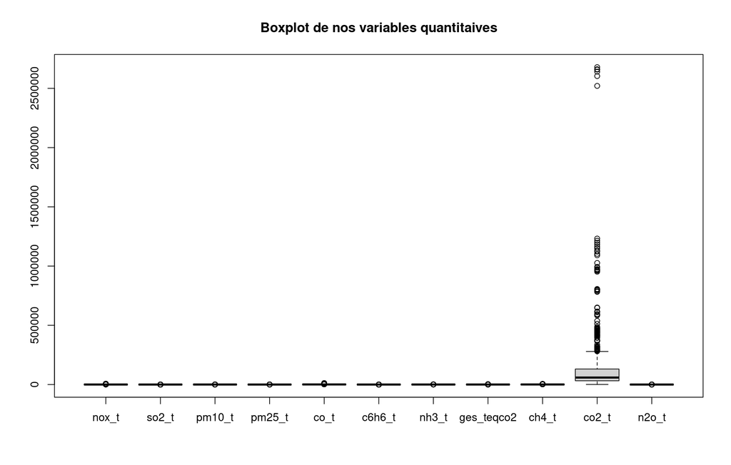

```r
boxplot(df[,ind_pol],main='Boxplot de nos variables quantitaives')
```

On remarque que la plupart des boxplots sont écrasés. La médiane pour chaque variable se situe autour de 0. On peut observer que de nombreux outliers sont présents pour la variable co2_t. De plus, celle-ci possède la plus grande variance. Effectuer une étude sur le jeu de données tel quel reviendrait donc à étudier uniquement la variable co2_t et nous perdrions donc beaucoup d’information.

### 3.2.2 Données log-transformées

Nous allons donc appliquer la fonction log pour pouvoir mieux observer nos variables.

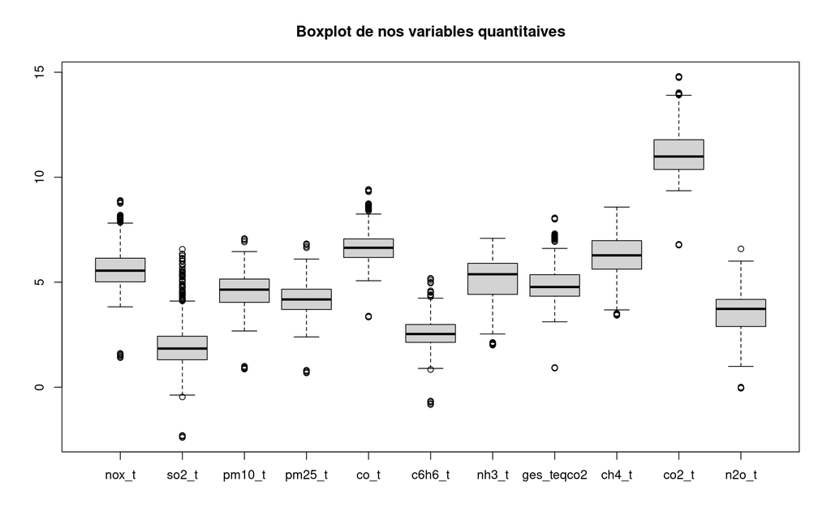

```r
df[,ind_pol]=log(df[,ind_pol])
boxplot(df[,ind_pol],main='Boxplot de nos variables quantitaives')
```

### 3.2.3 Données Centrées-Réduites

On remarque que les boxplots sont plus clairs et ont presque la même taille et donc les variables ont maintenant presque la même dispersion. Chaque variable possède quelques outliers. De plus, les données ayant la même unité, on va maintenant centrer les données.

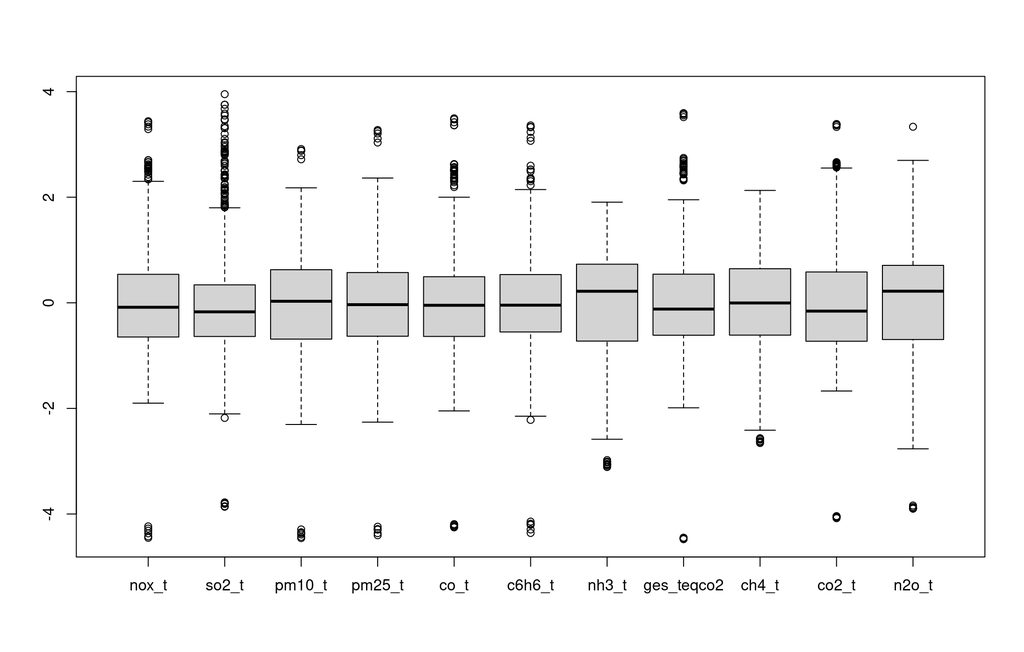

```r
df[,ind_pol] = scale(df[,ind_pol],center=TRUE,scale=TRUE)
boxplot(df[,ind_pol])
```

Les boxplots de nos données centrés ont à peu prés la même forme. On remarque aussi la présence de quelques outliers. On a décidé donc d’enlever les outliers.

```r
remove_outliers <- function(data_frame,columns) {
  # Définir le facteur d'échelle interquartile (IQR)
  iqr_factor <- 1.5

  # Appliquer la règle des quantiles pour chaque colonne
    for (col in columns) {
      # Calculer les quantiles
      q1 <- quantile(data_frame[[col]], 0.15)
      q3 <- quantile(data_frame[[col]], 0.85)

      # Calculer l'IQR
      iqr <- q3 - q1

      # Calculer les limites
      lower_limit <- q1 - iqr_factor * iqr
      upper_limit <- q3 + iqr_factor * iqr

      # Supprimer les outliers
      data_frame <- data_frame[data_frame[[col]] >= lower_limit & data_frame[[col]] <= upper_limit, ]
    }
  return(data_frame)
}
  df = remove_outliers(df,colnames(df)[ind_pol])
```

## 3.3 Analyse Unidimensionnelle

### 3.3.1 Variables quantitatives

Afin de réaliser l’analyse des variables quantitatives, nous allons réaliser les histogrammes des différentes variables. Pour un souci d’espace, on ne va afficher que l’histogramme d’une seule variable.

#### 3.3.1.1 Histogramme des variables quantitatives

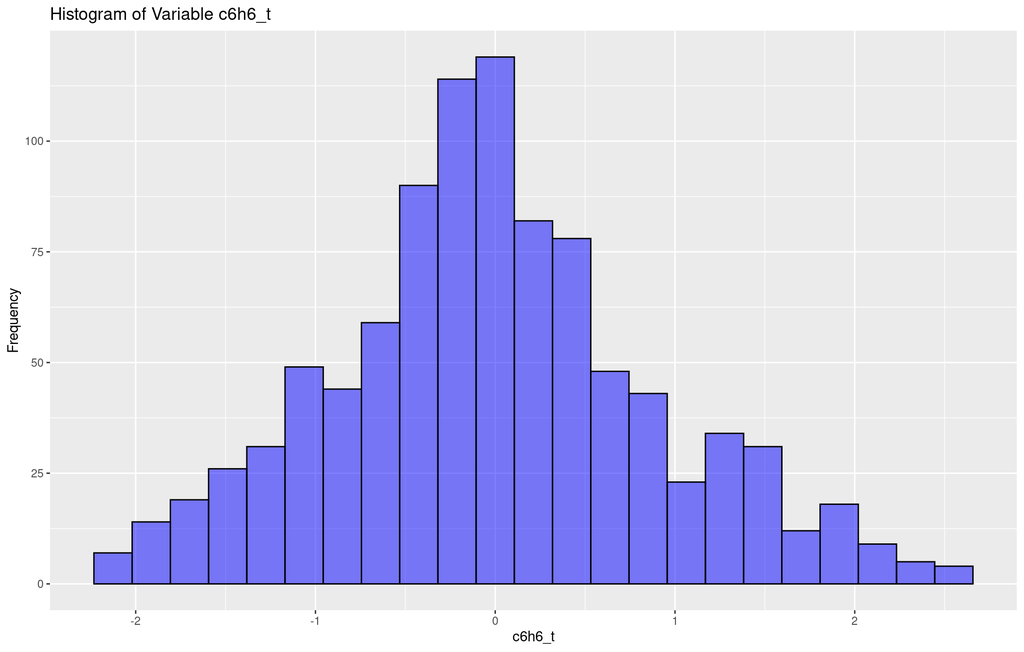

```r
#for (var in ind_pol) {
for (var in ind_pol[6:6]) {
  fd_binwidth <- (2 * IQR(df[, var])) / (length(df[, var])^(1/3))

  # Création de l'histogramme avec ggplot2
  p <- ggplot(df, aes_string(x = colnames(df)[var])) +
    geom_histogram(binwidth = fd_binwidth, fill = "blue", color = "black", alpha = 0.5) +
    labs(title = paste("Histogram of Variable", colnames(df)[var]),
         x = colnames(df)[var], y = "Frequency")

  # Forcer l'affichage du graphique
  print(p)
}
```

Nous observons que nos variables ont généralement bien une distribution gaussienne.

### 3.3.2 Variables qualitatives

#### 3.3.2.1 Barplots de nos variables qualitatives

[output not shown]

## 3.4 Analyse Bidimensionnelle

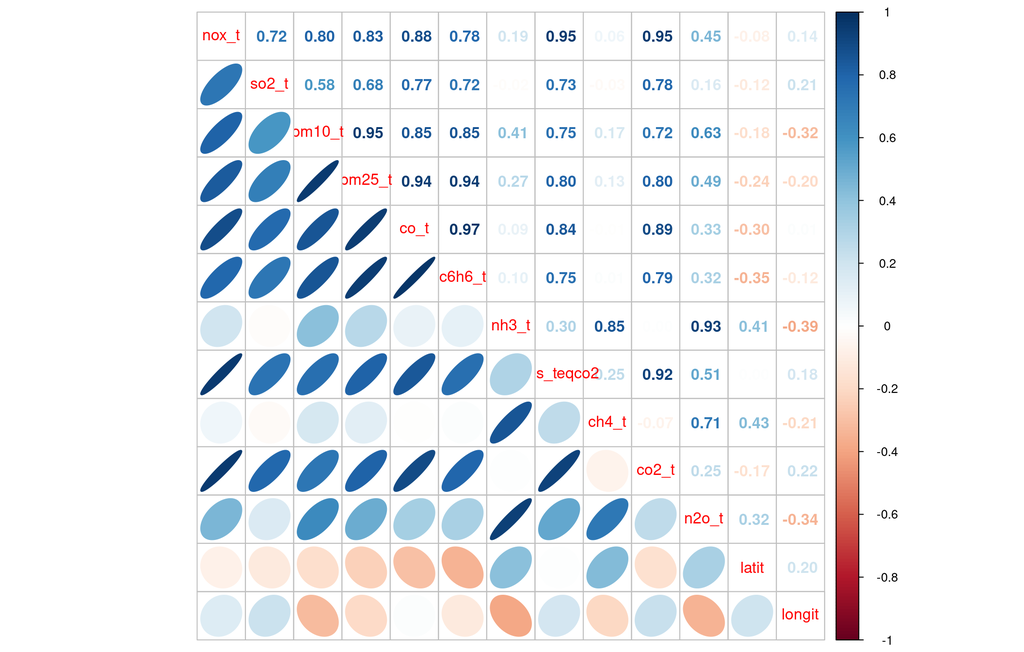

```r
corrplot.mixed(round(cor(df[,ind_quan]),2),lower = 'ellipse',upper='number',bg = "black")
```

On peut observer que certains polluants sont très corrélés entre eux positivement par exemple `co_t` et `pm25_t`, `co_t` et `c6h6_t`, `co2_t` et `ges_teqco2`, `co2_t` et `nox_t`. Il est intéressant également de remarquer qu’aucun polluant n’est très corrélé négativement avec un autre.

# 4 Méthodes Factorielles

## 4.1 Analyse en Composantes Principales

Réalisons maintenant une ACP sur notre jeux de donnée.

```r
acp_result <- PCA(df,quali.sup= ind_qual, graph = FALSE)
print(paste("Dim", 1:13, sep = "."))
```

```
##  [1] "Dim.1"  "Dim.2"  "Dim.3"  "Dim.4"  "Dim.5"  "Dim.6"  "Dim.7"  "Dim.8"
##  [9] "Dim.9"  "Dim.10" "Dim.11" "Dim.12" "Dim.13"
```

### 4.1.1 Variance Expliquée

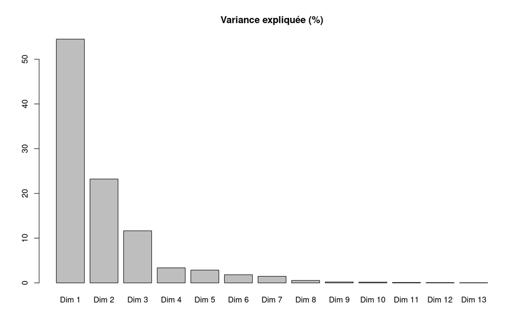

```r
barplot(acp_result$eig[,2], main="Variance expliquée (%)", names.arg=paste("Dim",1:nrow(acp_result$eig)))
```

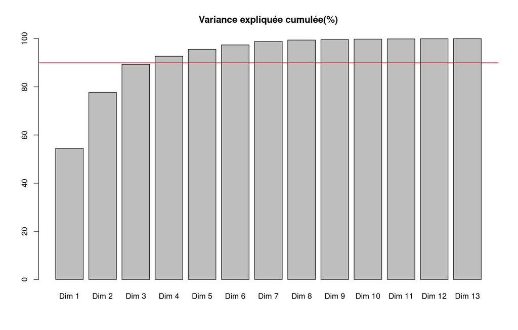

```r
barplot(acp_result$eig[,3], main="Variance expliquée cumulée(%)", names.arg=paste("Dim",1:nrow(acp_result$eig)))
abline(h=90,col='red')
```

> Nous remarquons grâce à ces graphes qu’en gardant trois composantes principales, on conserve près de 90% de l’inertie ce qui est très bien.

### 4.1.2 Graphe des individus

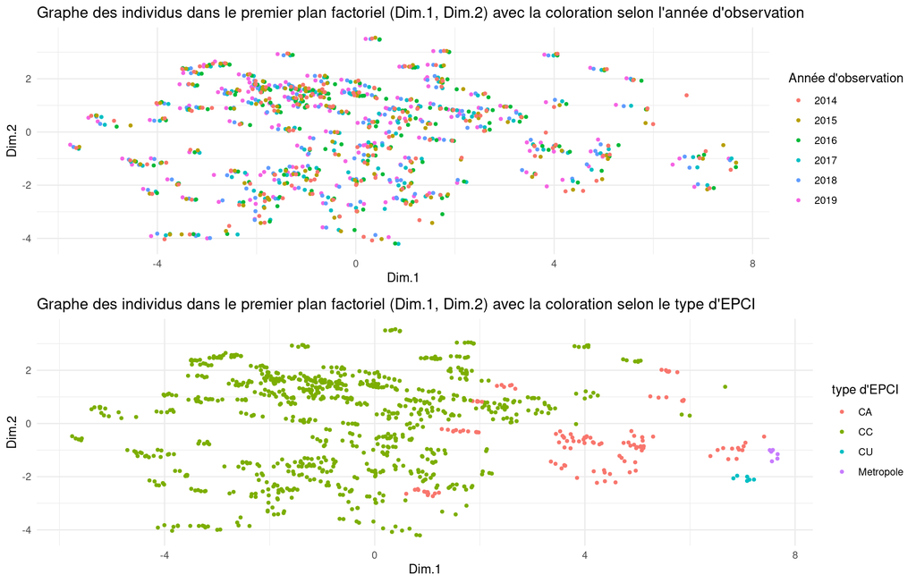

```r
gg_indiv1 <- ggplot(as.data.frame(acp_result$ind$coord), aes(x = Dim.1, y = Dim.2, colour = df$annee_inv)) +
  geom_point(size = 1) +
  labs(title = "Graphe des individus dans le premier plan factoriel (Dim.1, Dim.2) avec la coloration selon l'année d'observation", color = "Année d'observation") +
  theme_minimal()


gg_indiv2 <- ggplot(as.data.frame(acp_result$ind$coord), aes(x = Dim.1, y = Dim.2, colour = df$TypeEPCI)) +
  geom_point(size = 1) +
  labs(title = "Graphe des individus dans le premier plan factoriel (Dim.1, Dim.2) avec la coloration selon le type d'EPCI", color = "type d'EPCI") +
  theme_minimal()


grid.arrange(gg_indiv1, gg_indiv2, nrow = 2)
```

> Le premier graphe représente les individus en fonction des deux premières composantes principales. Ils sont colorés par année. On peut observer que les années ne sont pas regroupées entre elles. Ainsi, pour une même année EPCI, on retrouve tous les niveaux de pollution.

> Des outliers (de type **CC**) sont présents dans la partie gauche des deux graphiques. On remarque que ces observations ont tous été enregistrées pour des dates différentes.

### 4.1.3 Graphe des variables

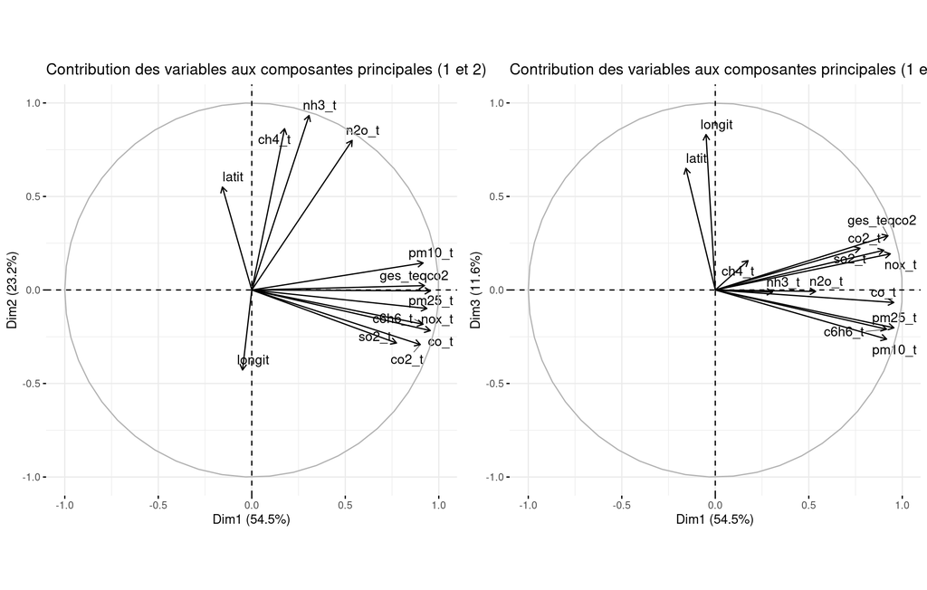

```r
# Visualisation de la contribution des variables à la première et à la deuxième composante principale
f1 = fviz_pca_var(acp_result,
             choice = "var", # Afficher la contribution des variables
             axes = c(1, 2),  # Axes à visualiser
             title = "Contribution des variables aux composantes principales (1 et 2)",
             repel = TRUE)    # Utiliser repel pour éviter le chevauchement des noms de variables

# Visualisation de la contribution des variables à la première et à la troisième composante principale
f2 = fviz_pca_var(acp_result,
             choice = "var", # Afficher la contribution des variables
             axes = c(1, 3),  # Axes à visualiser
             title = "Contribution des variables aux composantes principales (1 et 3)",
             repel = TRUE)    # Utiliser repel pour éviter le chevauchement des noms de variables
grid.arrange(f1, f2, ncol = 2)
```

> Nous pouvons analyser les composantes principales comme combinaison linéaire des différentes variables de façon suivante :

> `C1 = 0.9(pm10_t + ges_teqco2 + pm25_t + nox_t + c6h6_t + co_t + co2_t+ so2_t)`

> `C2 = 0.55latit + 0.7*(ch4_t + nh3_t + n2o_t) - 0.4longit`

> `C3 = 0.6*latit + 0.8*long`

> La première composante représente donc le gaz à effet de serre ainsi que les polluants qui y contribuent.

> La seconde composante représente donc le méthane, l’ammoniac, et le protoxyde d’azote.

#### 4.2.0.1 Discrétisation des Variables

> Concernant la discrétisation des variables, deux choix se présentent pour nous:
> - Soit on discrétise de façon à obtenir $I$ intervalles de même longueur mais pas nécessairement de même effectifs pour chaque variable.
> - Soit on utilise les quantiles de faon à obtenir $I$ intervalles de même effectifs mais pas nécessairement de même longueur.

> On a fait plutôt le premier choix. Toutefois, on a essayé de voir l’effectif de chaque intervalle pour s’assurer qu’il n’ait pas de modalité à faible effectif.

```r
df_mca = df
alpha <- c(0, 1/3, 2/3, 1)
breaks = 3
labels = letters[1:breaks]
for (ind in ind_quan) {
  col_name <- paste(colnames(df_mca)[ind], "")
  #quantiles = quantile(df_mca[[colnames(df_mca)[ind]]],probs= alpha)
  df_mca[[col_name]] <- cut(df_mca[[colnames(df_mca)[ind]]], breaks = breaks, labels =labels, include.lowest = TRUE)
}

ind_mca = c(15,16,37:49)
df_mca = df_mca[,ind_mca]
```

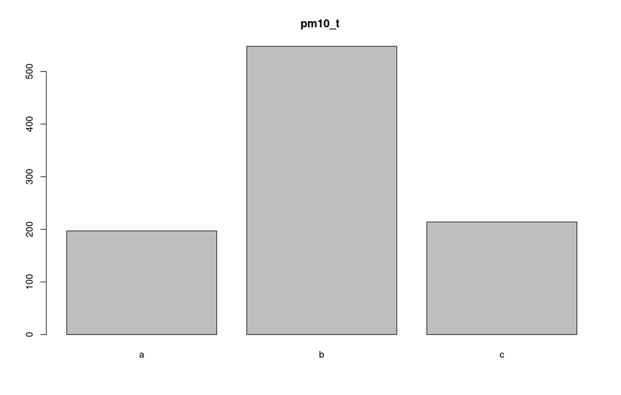

```r
#for (ind in 1:ncol(df_mca)){
for (ind in 6:6){
  barplot(table(df_mca[[ind]]),main=colnames(df_mca)[ind])
}
```

### 4.2.1 Application de la MCA

```r
# Appliquer la MCA
mca_result <- MCA(df_mca, graph = FALSE)
```

### 4.2.2 Graphes des modalités

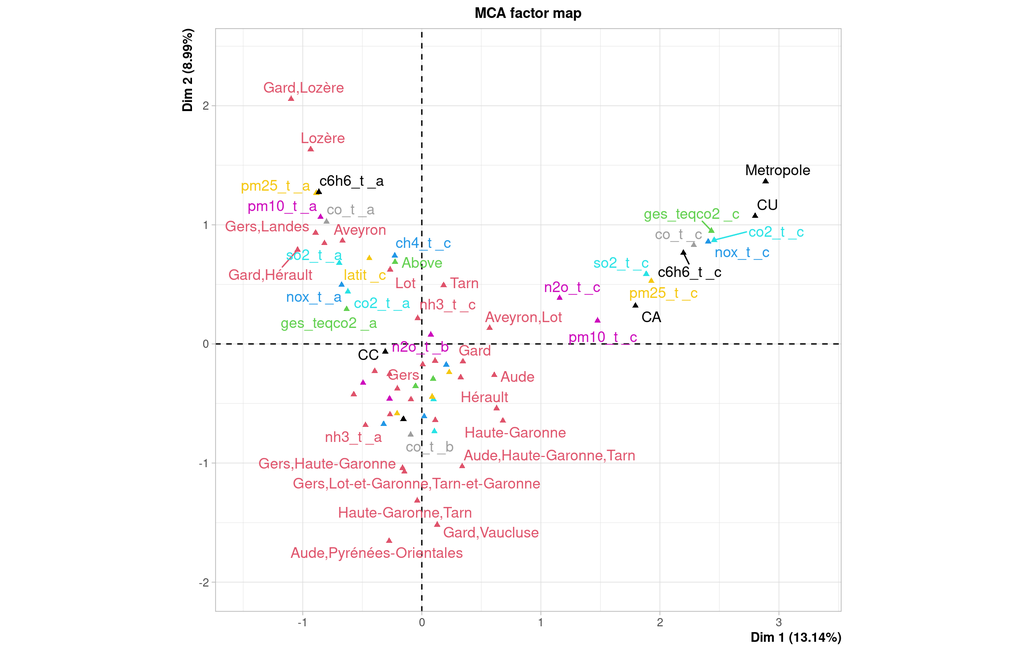

```r
plot(mca_result, axes = c(1, 2), choix = "ind", invisible = "ind", habillage = "quali", autoLab = "yes", graph.type = "ggplot")
```

## 4.3 Analyse Linéaire Discriminante

```r
lda_columns = c(ind_quan,15,3,37)
df_lda = df[lda_columns]
```

#### 4.3.0.1 LDA pour le Type d’EPCI

```r
lda_model_TypeEPCI <- lda(TypeEPCI ~., data = df_lda)
lda_predictions_TypeEPCI <- predict(lda_model_TypeEPCI)
```

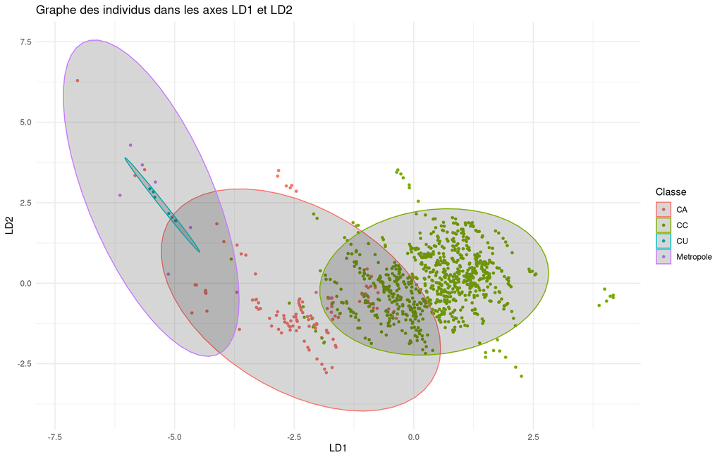

```r
library(ggplot2)
library(ggpubr)

# Création du dataframe avec les prédictions et les classes
df_plot <- data.frame(LD1 = lda_predictions_TypeEPCI$x[, 1],
                      LD2 = lda_predictions_TypeEPCI$x[, 2],
                      Classe = df_lda$TypeEPCI)

# Tracé du graphe avec ggplot2 et ajout d'ellipses
p <- ggplot(df_plot, aes(x = LD1, y = LD2, color = Classe)) +
  geom_point(size = 1) +  # Réduire la taille des points
  labs(title = "Graphe des individus dans les axes LD1 et LD2",
       x = "LD1",
       y = "LD2",
       color = "Classe") +
  theme_minimal() +
  theme(legend.position = "right")

# Ajout d'ellipses de confiance
p + stat_ellipse(type = "norm", geom = "polygon", alpha = 0.2)
```

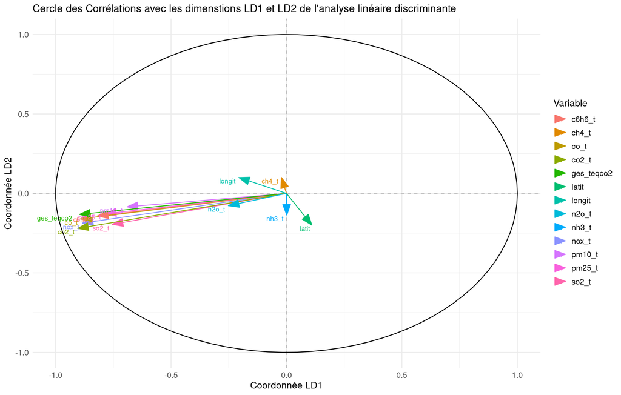

```r
coord_individus = lda_predictions_TypeEPCI$x
correlations_lda <- cor(df_lda[-c(14,15,16)],coord_individus)

Coord_ld1 = correlations_lda[,1]
Coord_ld2 = correlations_lda[,2]


variables_df <- data.frame(x = rep(0, length(Coord_ld1)),
                           y = rep(0, length(Coord_ld2)),
                           xend = Coord_ld1,
                           yend = Coord_ld2,
                           variable = names(Coord_ld1))  # Noms des variables


circle_df <- data.frame(x = cos(seq(0, 2 * pi, length.out = 100)),
                        y = sin(seq(0, 2 * pi, length.out = 100)))


ggplot() +
  geom_hline(yintercept = 0, linetype = "dashed", color = "gray") +
  geom_vline(xintercept = 0, linetype = "dashed", color = "gray") +
  geom_segment(data = variables_df, aes(x = x, y = y, xend = xend, yend = yend, color = variable),
               arrow = arrow(type = "closed", angle = 20, length = unit(0.2, "inches"))) +
  geom_text(data = variables_df, aes(x = xend, y = yend, label = variable, color = variable),
            hjust = 1.2, vjust = 1.2, size = 3) +
  geom_path(data = circle_df, aes(x, y), color = "black") +
  labs(title = "Cercle des Corrélations avec les dimenstions LD1 et LD2 de l'analyse linéaire discriminante",
       x = "Coordonnée LD1",
       y = "Coordonnée LD2",
       color = "Variable") +
  theme_minimal() +
  theme(legend.position = "right",
        axis.title = element_text(size = 12),
        axis.text = element_text(size = 10),
        legend.text = element_text(size = 10),
        legend.title = element_text(size = 12))
```

```r
lda_model_ch4_t <- lda(ch4_t_lda~., data = df_lda)
lda_predictions_ch4_t <- predict(lda_model_ch4_t)
```

# 5 Clustering

### 5.0.1 Kmeans

#### 5.0.1.1 Détermination du nombre de classe $k$ optimal

```r
df_kmeans = df[ind_quan]
```

##### 5.0.1.1.1 Intertie Intra-classe

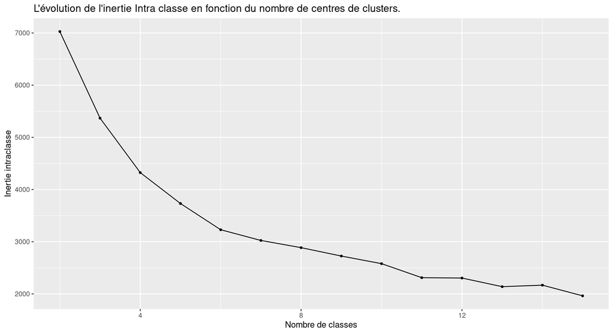

```r
Kmax<-15
reskmeanscl<-matrix(0,nrow=nrow(df_kmeans),ncol=Kmax-1)
Iintra<-NULL
for (k in 2:Kmax){
  resaux<-kmeans(df_kmeans,centers = k)
  reskmeanscl[,k-1]<-resaux$cluster
  Iintra<-c(Iintra,resaux$tot.withinss)
}

df_intra<-data.frame(K=2:15,Iintra=Iintra)
ggplot(df_intra,aes(x=K,y=Iintra))+geom_line()+geom_point(size=1)+xlab("Nombre de classes")+ylab("Inertie intraclasse") + labs(title = "L'évolution de l'inertie Intra classe en fonction du nombre de centres de clusters.")
```

##### 5.0.1.1.2 Silhouette

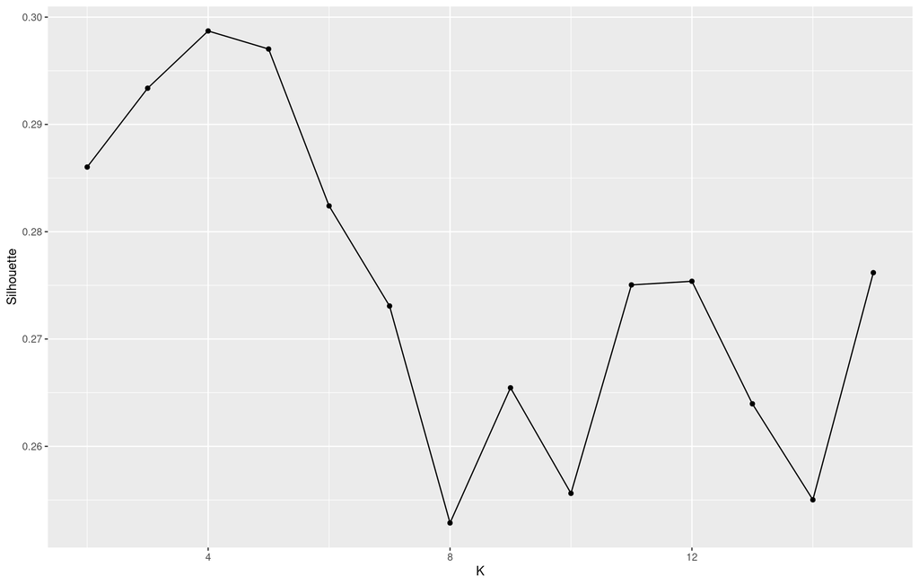

```r
library(cluster)
Silhou<-NULL
for (k in 2:Kmax){
  aux<-silhouette(reskmeanscl[,k-1],daisy(df_kmeans))
  Silhou<-c(Silhou,mean(aux[,3]))
}
df_silh<-data.frame(K=2:Kmax,Silhouette=Silhou)
ggplot(df_silh,aes(x=K,y=Silhouette))+
  geom_point()+
  geom_line()+theme(legend.position = "bottom")
```

```
##   cluster size ave.sil.width
## 1       1  148          0.38
## 2       2  205          0.31
## 3       3  205          0.23
## 4       4  112          0.28
## 5       5  158          0.30
## 6       6  131          0.21
```

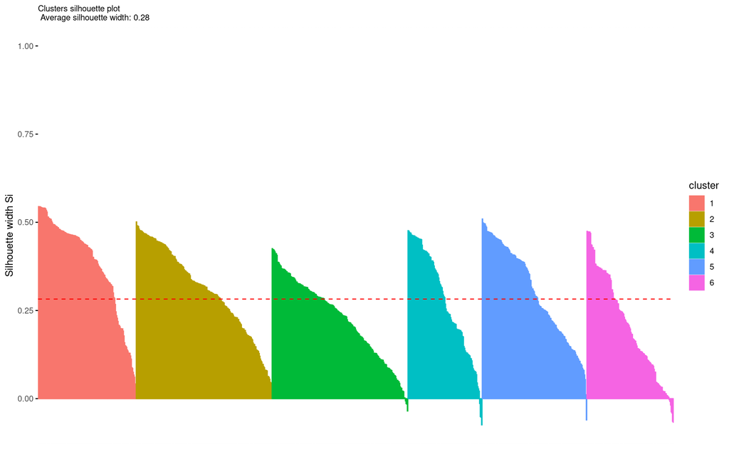

```r
aux<-silhouette(reskmeanscl[,5],daisy(df_kmeans))
fviz_silhouette(aux)+theme(plot.title = element_text(size =9))
```

```r
rm(df_silh,Silhou,aux)
```

##### 5.0.1.1.3 Calinski-Harabsz

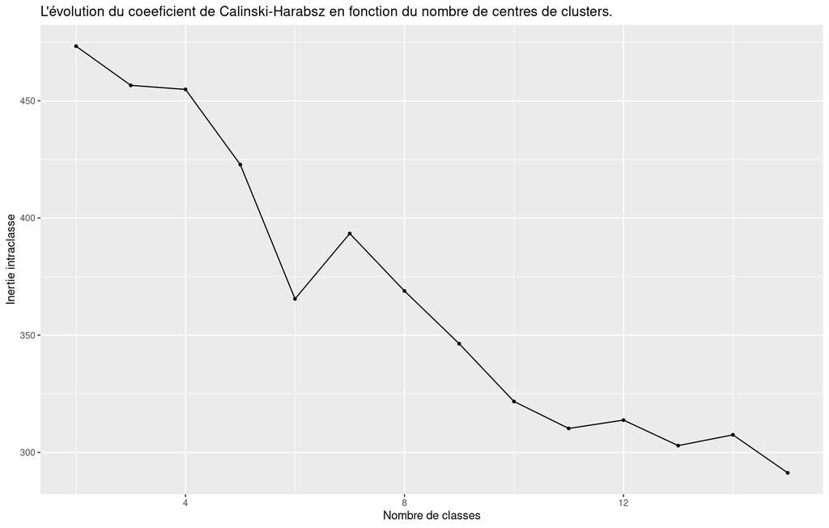

```r
Kmax<-15
reskmeanscl<-matrix(0,nrow=nrow(df_kmeans),ncol=Kmax-1)
Calin<-NULL
for (k in 2:Kmax){
  resaux<-kmeans(df_kmeans,centers = k)
  reskmeanscl[,k-1]<-resaux$cluster
  Iintra = resaux$tot.withinss
  Iinter = resaux$betweenss
  coef = (Iinter/(k-1))/(Iintra/(nrow(df_kmeans)-k))
  Calin<-c(Calin,coef)
}

df_Calin<-data.frame(K=2:15,Calin_Coef=Calin)
ggplot(df_Calin,aes(x=K,y=Calin_Coef))+geom_line()+geom_point(size=1)+xlab("Nombre de classes")+ylab("Inertie intraclasse") + labs(title = "L'évolution du coeeficient de Calinski-Harabsz en fonction du nombre de centres de clusters.")
```

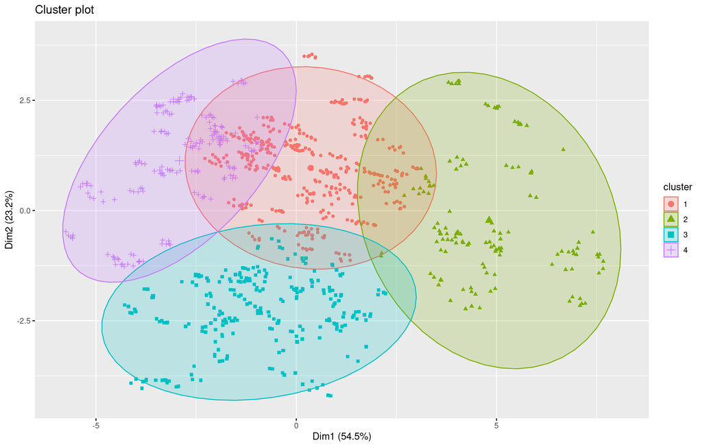

```r
reskmeans_def = kmeans(df_kmeans,centers = 4)

fviz_cluster(reskmeans_def,data=df_kmeans,axes=c(1,2),ellipse.type = "norm",labelsize = 8,geom=c("point"))
```

```r
adjustedRandIndex(reskmeans_def$cluster,df$TypeEPCI)
```

```
## [1] 0.1142881
```

### 5.0.2 Clustering Hiérarchique

```r
df_hierarchique = df_kmeans
dist_matrix <- dist(df_hierarchique)

res_hc<- hclust(dist_matrix, method = "ward.D2")
```

```r
str(res_hc)
```

```
## List of 7
##  $ merge      : int [1:958, 1:2] -479 -493 -676 -736 -727 -642 -772 -731 -738 -205 ...
##  $ height     : num [1:958] 0.0445 0.0492 0.0553 0.0559 0.0571 ...
##  $ order      : int [1:959] 57 216 693 854 375 534 65 224 702 863 ...
##  $ labels     : chr [1:959] "1" "2" "3" "4" ...
##  $ method     : chr "ward.D2"
##  $ call       : language hclust(d = dist_matrix, method = "ward.D2")
##  $ dist.method: chr "euclidean"
##  - attr(*, "class")= chr "hclust"
```

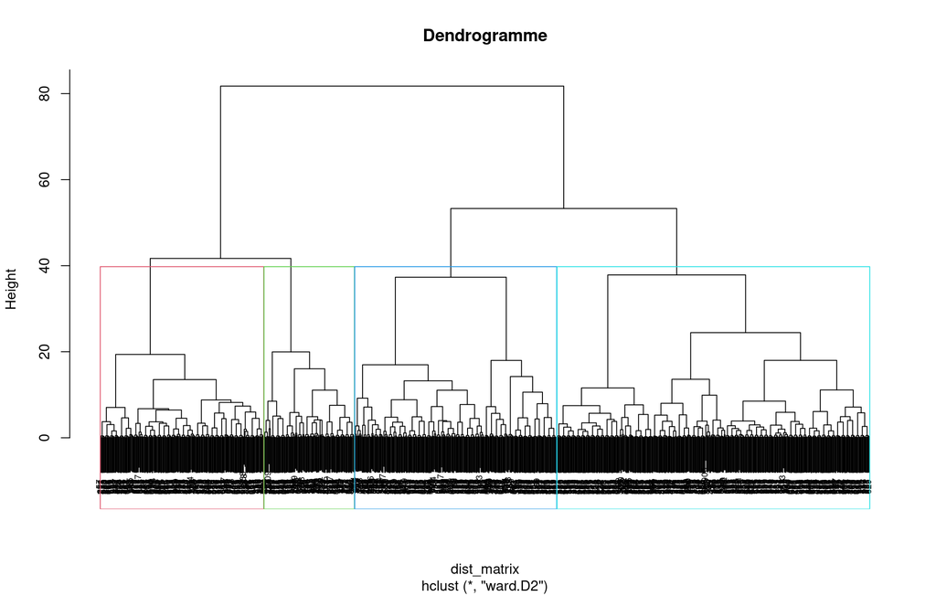

```r
plot(res_hc, cex = 0.6, main = "Dendrogramme")

# Ajouter des labels aux branches du dendrogramme
rect.hclust(res_hc, k = 4, border = 2:5)
```

#### 5.0.2.1 Détermination du nombre de classe $k$ optimal

##### 5.0.2.1.1 Intertie Intra-classe

```r
Kmax <- 15
Iintra_hierarchical <- numeric(Kmax - 1)

for (k in 2:Kmax) {
  cutree_clusters <- cutree(res_hc, k)
  str(cutree_clusters)
  total_withinss <- 0
  for (i in 1:k) {
    cluster_points <- which(cutree_clusters == i)
    cluster_data <- df_kmeans[cluster_points, ]
    total_withinss <- total_withinss + sum(dist(cluster_data)^2)
  }

  Iintra_hierarchical[k - 1] <- total_withinss
}
```

[output not shown]

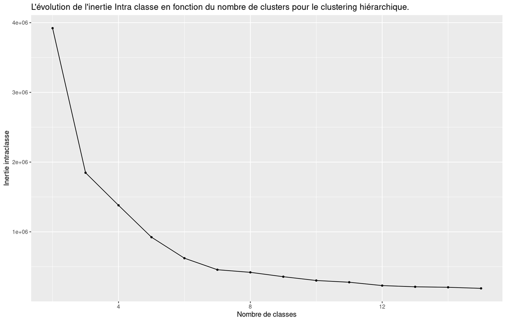

```r
df_intra_hierarchical <- data.frame(K = 2:15, Iintra = Iintra_hierarchical)



ggplot(df_intra_hierarchical, aes(x = K, y = Iintra)) +
  geom_line() +
  geom_point(size = 1) +
  xlab("Nombre de classes") +
  ylab("Inertie intraclasse") +
  labs(title = "L'évolution de l'inertie Intra classe en fonction du nombre de clusters pour le clustering hiérarchique.")
```

# 6 Modèle Linéaire et Modèle linéaire Généralisé

## 6.1 Régression linéaire Multiple : Gaz à effet de serre en fonction des polluants

```r
ind_regmulti = c(4:14)
df_regmulti = df[,ind_regmulti]
```

### 6.1.1 Regression linéaire en incluant toutes les variables

```r
mod_reg_multi = lm(ges_teqco2 ~ . ,data =df_regmulti)
summary(mod_reg_multi)
```

```
##
## Call:
## lm(formula = ges_teqco2 ~ ., data = df_regmulti)
##
## Residuals:
##      Min       1Q   Median       3Q      Max
## -0.55525 -0.09027 -0.01230  0.06137  0.88949
##
## Coefficients:
##              Estimate Std. Error t value Pr(>|t|)
## (Intercept) -0.008201   0.004786  -1.714 0.086926 .
## nox_t        0.267759   0.030125   8.888  < 2e-16 ***
## so2_t        0.036316   0.009534   3.809 0.000148 ***
## pm10_t      -0.271206   0.030295  -8.952  < 2e-16 ***
## pm25_t       0.157159   0.037777   4.160 3.47e-05 ***
## co_t        -0.009881   0.051616  -0.191 0.848228
## c6h6_t       0.001898   0.042850   0.044 0.964676
## nh3_t       -0.279798   0.029280  -9.556  < 2e-16 ***
## ch4_t        0.244085   0.012347  19.769  < 2e-16 ***
## co2_t        0.604444   0.031403  19.248  < 2e-16 ***
## n2o_t        0.393794   0.030976  12.713  < 2e-16 ***
## ---
## Signif. codes:  0 '***' 0.001 '**' 0.01 '*' 0.05 '.' 0.1 ' ' 1
##
## Residual standard error: 0.1479 on 948 degrees of freedom
## Multiple R-squared:  0.9715, Adjusted R-squared:  0.9712
## F-statistic:  3235 on 10 and 948 DF,  p-value: < 2.2e-16
```

### 6.1.2 Sélection de variables

```r
library(leaps)
select = regsubsets(ges_teqco2 ~ . ,data =df_regmulti,nbest=1,nvmax=100,method="backward")
```

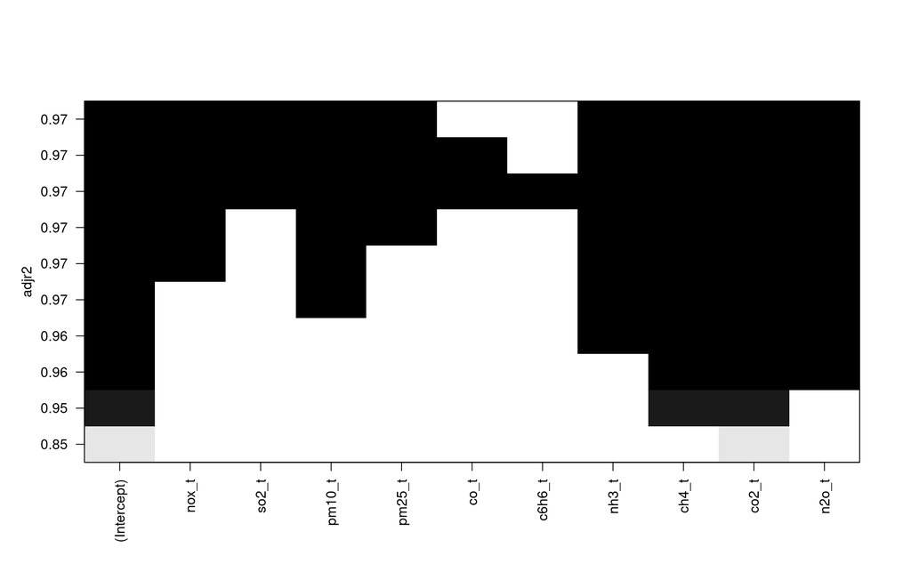

```r
plot(select,scale="adjr2")
```

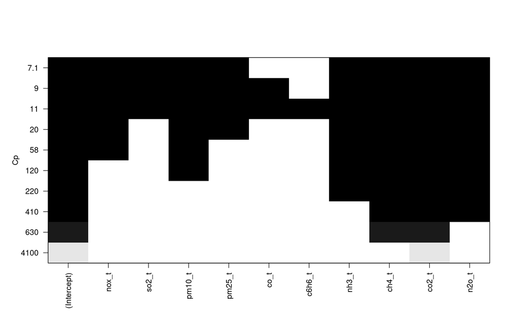

```r
plot(select,scale="Cp")
```

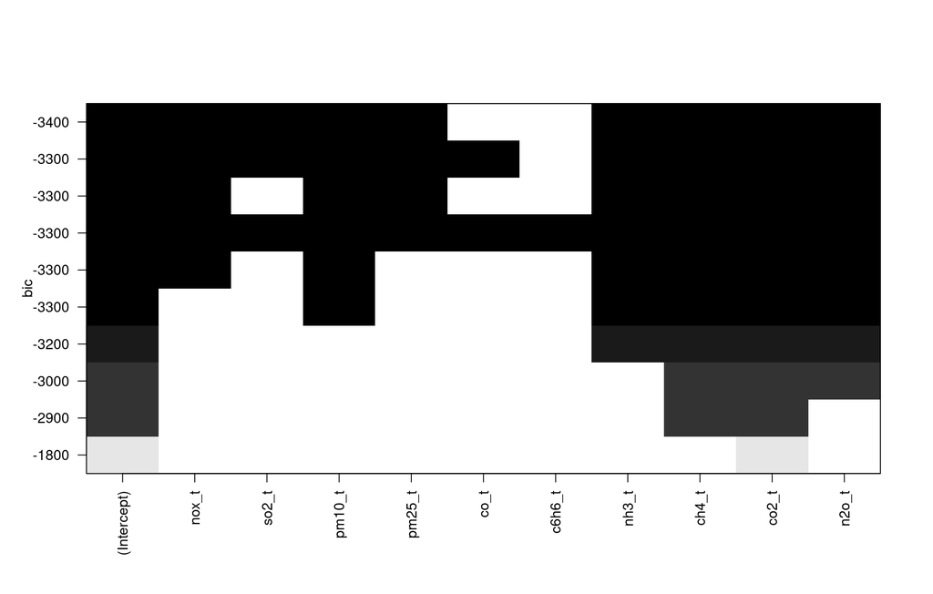

```r
plot(select,scale="bic")
```

```r
modbest = lm(ges_teqco2 ~ nox_t + so2_t + pm10_t + pm25_t + +nh3_t + ch4_t + co2_t + n2o_t,data=df_regmulti )
summary(modbest)
```

```
##
## Call:
## lm(formula = ges_teqco2 ~ nox_t + so2_t + pm10_t + pm25_t + +nh3_t +
##     ch4_t + co2_t + n2o_t, data = df_regmulti)
##
## Residuals:
##      Min       1Q   Median       3Q      Max
## -0.55691 -0.09026 -0.01221  0.06120  0.88841
##
## Coefficients:
##              Estimate Std. Error t value Pr(>|t|)
## (Intercept) -0.008231   0.004779  -1.722 0.085353 .
## nox_t        0.267936   0.030043   8.918  < 2e-16 ***
## so2_t        0.035929   0.009432   3.809 0.000148 ***
## pm10_t      -0.268185   0.028898  -9.280  < 2e-16 ***
## pm25_t       0.149764   0.027425   5.461 6.05e-08 ***
## nh3_t       -0.279065   0.029166  -9.568  < 2e-16 ***
## ch4_t        0.244695   0.012147  20.145  < 2e-16 ***
## co2_t        0.601351   0.027201  22.108  < 2e-16 ***
## n2o_t        0.392467   0.030509  12.864  < 2e-16 ***
## ---
## Signif. codes:  0 '***' 0.001 '**' 0.01 '*' 0.05 '.' 0.1 ' ' 1
##
## Residual standard error: 0.1477 on 950 degrees of freedom
## Multiple R-squared:  0.9715, Adjusted R-squared:  0.9713
## F-statistic:  4052 on 8 and 950 DF,  p-value: < 2.2e-16
```

```r
anova(modbest,mod_reg_multi)
```

```
## Analysis of Variance Table
##
## Model 1: ges_teqco2 ~ nox_t + so2_t + pm10_t + pm25_t + +nh3_t + ch4_t +
##     co2_t + n2o_t
## Model 2: ges_teqco2 ~ nox_t + so2_t + pm10_t + pm25_t + co_t + c6h6_t +
##     nh3_t + ch4_t + co2_t + n2o_t
##   Res.Df    RSS Df Sum of Sq      F Pr(>F)
## 1    950 20.737
## 2    948 20.735  2 0.0024644 0.0563 0.9452
```

## 6.2 Anova

```r
modeleanova<-lm(ges_teqco2~TypeEPCI*annee_inv,data = data)
modeleanovaadd<-lm(ges_teqco2~TypeEPCI+annee_inv,data = data)
summary(modeleanova)
```

```
##
## Call:
## lm(formula = ges_teqco2 ~ TypeEPCI * annee_inv, data = data)
##
## Residuals:
##     Min      1Q  Median      3Q     Max
## -865721  -66010  -33713   22247 1174580
##
## Coefficients:
##                                 Estimate Std. Error t value Pr(>|t|)
## (Intercept)                       455581      40674  11.201  < 2e-16 ***
## TypeEPCICC                       -324794      43618  -7.446 2.13e-13 ***
## TypeEPCICU                        570140     190779   2.988  0.00288 **
## TypeEPCIMetropole                1690136     137933  12.253  < 2e-16 ***
## annee_inv2015                      11637      57522   0.202  0.83972
## annee_inv2016                      19942      57522   0.347  0.72890
## annee_inv2017                      21133      57522   0.367  0.71340
## annee_inv2018                      21619      57522   0.376  0.70711
## annee_inv2019                      22741      57522   0.395  0.69268
## TypeEPCICC:annee_inv2015           -9302      61686  -0.151  0.88017
## TypeEPCICU:annee_inv2015           -4335     269803  -0.016  0.98718
## TypeEPCIMetropole:annee_inv2015    59851     195067   0.307  0.75905
## TypeEPCICC:annee_inv2016          -14262      61686  -0.231  0.81721
## TypeEPCICU:annee_inv2016            5485     269803   0.020  0.98378
## TypeEPCIMetropole:annee_inv2016   104252     195067   0.534  0.59316
## TypeEPCICC:annee_inv2017          -14607      61686  -0.237  0.81286
## TypeEPCICU:annee_inv2017           11380     269803   0.042  0.96637
## TypeEPCIMetropole:annee_inv2017   136456     195067   0.700  0.48439
## TypeEPCICC:annee_inv2018          -15520      61686  -0.252  0.80141
## TypeEPCICU:annee_inv2018           -1062     269803  -0.004  0.99686
## TypeEPCIMetropole:annee_inv2018   146937     195067   0.753  0.45147
## TypeEPCICC:annee_inv2019          -18062      61686  -0.293  0.76973
## TypeEPCICU:annee_inv2019            9299     269803   0.034  0.97251
## TypeEPCIMetropole:annee_inv2019   165248     195067   0.847  0.39713
## ---
## Signif. codes:  0 '***' 0.001 '**' 0.01 '*' 0.05 '.' 0.1 ' ' 1
##
## Residual standard error: 186400 on 960 degrees of freedom
## Multiple R-squared:  0.6717, Adjusted R-squared:  0.6638
## F-statistic: 85.39 on 23 and 960 DF,  p-value: < 2.2e-16
```

```r
summary(modeleanovaadd)
```

```
##
## Call:
## lm(formula = ges_teqco2 ~ TypeEPCI + annee_inv, data = data)
##
## Residuals:
##     Min      1Q  Median      3Q     Max
## -934356  -66270  -33117   21993 1173725
##
## Coefficients:
##                   Estimate Std. Error t value Pr(>|t|)
## (Intercept)         464523      21118  21.996  < 2e-16 ***
## TypeEPCICC         -336753      17683 -19.044  < 2e-16 ***
## TypeEPCICU          573601      77342   7.416 2.61e-13 ***
## TypeEPCIMetropole  1792260      55918  32.052  < 2e-16 ***
## annee_inv2015         4400      20440   0.215    0.830
## annee_inv2016         9072      20440   0.444    0.657
## annee_inv2017        10397      20440   0.509    0.611
## annee_inv2018        10156      20440   0.497    0.619
## annee_inv2019         9394      20440   0.460    0.646
## ---
## Signif. codes:  0 '***' 0.001 '**' 0.01 '*' 0.05 '.' 0.1 ' ' 1
##
## Residual standard error: 185100 on 975 degrees of freedom
## Multiple R-squared:  0.6712, Adjusted R-squared:  0.6685
## F-statistic: 248.8 on 8 and 975 DF,  p-value: < 2.2e-16
```

```r
anova(modeleanovaadd,modeleanova)
```

```
## Analysis of Variance Table
##
## Model 1: ges_teqco2 ~ TypeEPCI + annee_inv
## Model 2: ges_teqco2 ~ TypeEPCI * annee_inv
##   Res.Df        RSS Df  Sum of Sq      F Pr(>F)
## 1    975 3.3402e+13
## 2    960 3.3353e+13 15 4.9752e+10 0.0955      1
```

```r
modeleannee<-lm(ges_teqco2~annee_inv,data = data)
anova(modeleannee,modeleanovaadd)
```

```
## Analysis of Variance Table
##
## Model 1: ges_teqco2 ~ annee_inv
## Model 2: ges_teqco2 ~ TypeEPCI + annee_inv
##   Res.Df        RSS Df  Sum of Sq      F    Pr(>F)
## 1    978 1.0157e+14
## 2    975 3.3402e+13  3 6.8172e+13 663.31 < 2.2e-16 ***
## ---
## Signif. codes:  0 '***' 0.001 '**' 0.01 '*' 0.05 '.' 0.1 ' ' 1
```

```r
modeletype<-lm(ges_teqco2~TypeEPCI,data = data)
anova(modeletype,modeleanovaadd)
```

```
## Analysis of Variance Table
##
## Model 1: ges_teqco2 ~ TypeEPCI
## Model 2: ges_teqco2 ~ TypeEPCI + annee_inv
##   Res.Df        RSS Df  Sum of Sq      F Pr(>F)
## 1    980 3.3417e+13
## 2    975 3.3402e+13  5 1.4261e+10 0.0833 0.9949
```

```r
modelenull<-lm(ges_teqco2~1,data = data)
anova(modelenull,modeletype)
```

```
## Analysis of Variance Table
##
## Model 1: ges_teqco2 ~ 1
## Model 2: ges_teqco2 ~ TypeEPCI
##   Res.Df        RSS Df  Sum of Sq      F    Pr(>F)
## 1    983 1.0159e+14
## 2    980 3.3417e+13  3 6.8172e+13 666.42 < 2.2e-16 ***
## ---
## Signif. codes:  0 '***' 0.001 '**' 0.01 '*' 0.05 '.' 0.1 ' ' 1
```

```r
summary(modeletype)
```

```
##
## Call:
## lm(formula = ges_teqco2 ~ TypeEPCI, data = data)
##
## Residuals:
##     Min      1Q  Median      3Q     Max
## -941592  -65718  -34335   23368 1176886
##
## Coefficients:
##                   Estimate Std. Error t value Pr(>|t|)
## (Intercept)         471760      16451  28.677  < 2e-16 ***
## TypeEPCICC         -336753      17641 -19.089  < 2e-16 ***
## TypeEPCICU          573601      77160   7.434  2.3e-13 ***
## TypeEPCIMetropole  1792260      55787  32.127  < 2e-16 ***
## ---
## Signif. codes:  0 '***' 0.001 '**' 0.01 '*' 0.05 '.' 0.1 ' ' 1
##
## Residual standard error: 184700 on 980 degrees of freedom
## Multiple R-squared:  0.6711, Adjusted R-squared:  0.6701
## F-statistic: 666.4 on 3 and 980 DF,  p-value: < 2.2e-16
```

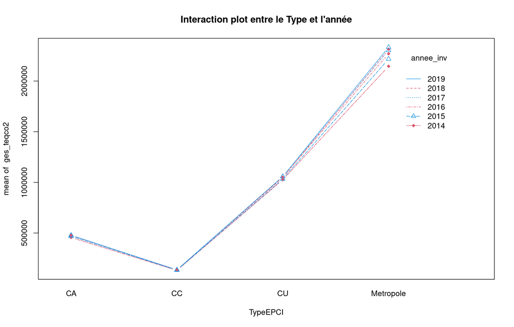

```r
attach(data)
interaction.plot(TypeEPCI,annee_inv,ges_teqco2,col=c(2,4),pch=c(18,24),main="Interaction plot entre le Type et l'année",type="b")
```

## 6.3 Ancova

```r
modeleancova<-lm(ch4_t~TypeEPCI*annee_inv*nh3_kg*co_kg,data = data)
modeleancovasansinter<-lm(ch4_t~TypeEPCI+annee_inv+nh3_kg+co_kg,data = data)
summary(modeleancova)
```

```
##
## Call:
## lm(formula = ch4_t ~ TypeEPCI * annee_inv * nh3_kg * co_kg, data = data)
##
## Residuals:
##      Min       1Q   Median       3Q      Max
## -2114.31  -175.60    52.64   219.29  1265.73
##
## Coefficients: (30 not defined because of singularities)
##                                                Estimate Std. Error t value
## (Intercept)                                   4.488e+02  4.834e+02   0.928
## TypeEPCICC                                   -3.406e+02  5.023e+02  -0.678
## TypeEPCICU                                    4.698e+02  6.787e+02   0.692
## TypeEPCIMetropole                             2.717e+03  1.934e+03   1.405
## annee_inv2015                                 3.533e+00  6.643e+02   0.005
## annee_inv2016                                 5.992e+01  6.653e+02   0.090
## annee_inv2017                                 1.074e+02  6.718e+02   0.160
## annee_inv2018                                 8.189e+01  6.619e+02   0.124
## annee_inv2019                                -2.382e+01  6.663e+02  -0.036
## nh3_kg                                        1.967e-03  2.155e-03   0.913
## co_kg                                        -1.191e-04  1.802e-04  -0.661
## TypeEPCICC:annee_inv2015                      3.090e+01  6.916e+02   0.045
## TypeEPCICU:annee_inv2015                     -8.361e+01  9.327e+02  -0.090
## TypeEPCIMetropole:annee_inv2015              -3.687e+05  6.107e+05  -0.604
## TypeEPCICC:annee_inv2016                     -1.604e+01  6.926e+02  -0.023
## TypeEPCICU:annee_inv2016                     -3.231e+01  9.430e+02  -0.034
## TypeEPCIMetropole:annee_inv2016               1.076e+03  3.287e+03   0.327
## TypeEPCICC:annee_inv2017                     -3.316e+01  6.994e+02  -0.047
## TypeEPCICU:annee_inv2017                     -7.328e+01  9.416e+02  -0.078
## TypeEPCIMetropole:annee_inv2017               2.339e+04  3.757e+04   0.622
## TypeEPCICC:annee_inv2018                      3.334e+01  6.901e+02   0.048
## TypeEPCICU:annee_inv2018                     -2.105e+02  9.388e+02  -0.224
## TypeEPCIMetropole:annee_inv2018               2.755e+02  2.021e+03   0.136
## TypeEPCICC:annee_inv2019                      1.185e+02  6.941e+02   0.171
## TypeEPCICU:annee_inv2019                     -3.550e+02  9.520e+02  -0.373
## TypeEPCIMetropole:annee_inv2019               2.981e+03  4.022e+03   0.741
## TypeEPCICC:nh3_kg                             2.299e-03  2.183e-03   1.053
## TypeEPCICU:nh3_kg                                    NA         NA      NA
## TypeEPCIMetropole:nh3_kg                     -5.556e-02  7.803e-02  -0.712
## annee_inv2015:nh3_kg                         -3.666e-04  2.991e-03  -0.123
```

[output cut: 152 more lines]

```
## TypeEPCICU:annee_inv2016:nh3_kg:co_kg              NA
## TypeEPCIMetropole:annee_inv2016:nh3_kg:co_kg       NA
## TypeEPCICC:annee_inv2017:nh3_kg:co_kg           0.973
## TypeEPCICU:annee_inv2017:nh3_kg:co_kg              NA
## TypeEPCIMetropole:annee_inv2017:nh3_kg:co_kg       NA
## TypeEPCICC:annee_inv2018:nh3_kg:co_kg           0.945
## TypeEPCICU:annee_inv2018:nh3_kg:co_kg              NA
## TypeEPCIMetropole:annee_inv2018:nh3_kg:co_kg       NA
## TypeEPCICC:annee_inv2019:nh3_kg:co_kg           0.923
## TypeEPCICU:annee_inv2019:nh3_kg:co_kg              NA
## TypeEPCIMetropole:annee_inv2019:nh3_kg:co_kg       NA
##
## Residual standard error: 493.2 on 918 degrees of freedom
## Multiple R-squared:  0.7729, Adjusted R-squared:  0.7568
## F-statistic: 48.06 on 65 and 918 DF,  p-value: < 2.2e-16
```

```r
anova(modeleancovasansinter,modeleancova)
```

```
## Analysis of Variance Table
##
## Model 1: ch4_t ~ TypeEPCI + annee_inv + nh3_kg + co_kg
## Model 2: ch4_t ~ TypeEPCI * annee_inv * nh3_kg * co_kg
##   Res.Df       RSS Df Sum of Sq      F    Pr(>F)
## 1    973 253142933
## 2    918 223341999 55  29800933 2.2271 1.599e-06 ***
## ---
## Signif. codes:  0 '***' 0.001 '**' 0.01 '*' 0.05 '.' 0.1 ' ' 1
```

```r
modeleancovasanstypeinter<-lm(ch4_t~TypeEPCI+annee_inv*nh3_kg*co_kg,data = data)
modeleancovasansanneeinter<-lm(ch4_t~annee_inv+TypeEPCI*nh3_kg*co_kg,data = data)
modeleancovasanscointer<-lm(ch4_t~co_kg+TypeEPCI*annee_inv*nh3_kg,data = data)
modeleancovasansnh3inter<-lm(ch4_t~nh3_kg+TypeEPCI*annee_inv*co_kg,data = data)
anova(modeleancovasanstypeinter,modeleancova)
```

```
## Analysis of Variance Table
##
## Model 1: ch4_t ~ TypeEPCI + annee_inv * nh3_kg * co_kg
## Model 2: ch4_t ~ TypeEPCI * annee_inv * nh3_kg * co_kg
##   Res.Df       RSS Df Sum of Sq      F    Pr(>F)
## 1    957 243553424
## 2    918 223341999 39  20211425 2.1301 8.772e-05 ***
## ---
## Signif. codes:  0 '***' 0.001 '**' 0.01 '*' 0.05 '.' 0.1 ' ' 1
```

```r
anova(modeleancovasansanneeinter,modeleancova)
```

```
## Analysis of Variance Table
##
## Model 1: ch4_t ~ annee_inv + TypeEPCI * nh3_kg * co_kg
## Model 2: ch4_t ~ TypeEPCI * annee_inv * nh3_kg * co_kg
##   Res.Df       RSS Df Sum of Sq      F Pr(>F)
## 1    963 227344224
## 2    918 223341999 45   4002224 0.3656      1
```

```r
anova(modeleancovasanscointer,modeleancova)
```

```
## Analysis of Variance Table
##
## Model 1: ch4_t ~ co_kg + TypeEPCI * annee_inv * nh3_kg
## Model 2: ch4_t ~ TypeEPCI * annee_inv * nh3_kg * co_kg
##   Res.Df       RSS Df Sum of Sq      F  Pr(>F)
## 1    941 231425237
## 2    918 223341999 23   8083238 1.4445 0.08092 .
## ---
## Signif. codes:  0 '***' 0.001 '**' 0.01 '*' 0.05 '.' 0.1 ' ' 1
```

```r
anova(modeleancovasansnh3inter,modeleancova)
```

```
## Analysis of Variance Table
##
## Model 1: ch4_t ~ nh3_kg + TypeEPCI * annee_inv * co_kg
## Model 2: ch4_t ~ TypeEPCI * annee_inv * nh3_kg * co_kg
##   Res.Df       RSS Df Sum of Sq      F    Pr(>F)
## 1    941 249044240
## 2    918 223341999 23  25702241 4.5932 8.996e-12 ***
## ---
## Signif. codes:  0 '***' 0.001 '**' 0.01 '*' 0.05 '.' 0.1 ' ' 1
```

```r
modeleancovasansannee_typeinter<-lm(ch4_t~annee_inv+TypeEPCI+nh3_kg*co_kg,data = data)
modeleancovasansannee_nh3inter<-lm(ch4_t~annee_inv+nh3_kg+TypeEPCI*co_kg,data = data)
modeleancovasansannee_cointer<-lm(ch4_t~annee_inv+co_kg+nh3_kg*TypeEPCI,data = data)
anova(modeleancovasansanneeinter,modeleancovasansannee_typeinter)
```

```
## Analysis of Variance Table
##
## Model 1: ch4_t ~ annee_inv + TypeEPCI * nh3_kg * co_kg
## Model 2: ch4_t ~ annee_inv + TypeEPCI + nh3_kg * co_kg
##   Res.Df       RSS Df Sum of Sq      F    Pr(>F)
## 1    963 227344224
## 2    972 247098835 -9 -19754611 9.2975 1.268e-13 ***
## ---
## Signif. codes:  0 '***' 0.001 '**' 0.01 '*' 0.05 '.' 0.1 ' ' 1
```

```r
anova(modeleancovasansanneeinter,modeleancovasansannee_nh3inter)
```

```
## Analysis of Variance Table
##
## Model 1: ch4_t ~ annee_inv + TypeEPCI * nh3_kg * co_kg
## Model 2: ch4_t ~ annee_inv + nh3_kg + TypeEPCI * co_kg
##   Res.Df       RSS Df Sum of Sq      F    Pr(>F)
## 1    963 227344224
## 2    970 250786761 -7 -23442537 14.186 < 2.2e-16 ***
## ---
## Signif. codes:  0 '***' 0.001 '**' 0.01 '*' 0.05 '.' 0.1 ' ' 1
```

```r
anova(modeleancovasansanneeinter,modeleancovasansannee_cointer)
```

```
## Analysis of Variance Table
##
## Model 1: ch4_t ~ annee_inv + TypeEPCI * nh3_kg * co_kg
## Model 2: ch4_t ~ annee_inv + co_kg + nh3_kg * TypeEPCI
##   Res.Df       RSS Df Sum of Sq      F    Pr(>F)
## 1    963 227344224
## 2    970 235709606 -7  -8365382 5.0621 1.174e-05 ***
## ---
## Signif. codes:  0 '***' 0.001 '**' 0.01 '*' 0.05 '.' 0.1 ' ' 1
```

```r
modeleancovasansannee<-lm(ch4_t~TypeEPCI*nh3_kg*co_kg,data = data)
anova(modeleancovasansannee,modeleancovasansanneeinter)
```

```
## Analysis of Variance Table
##
## Model 1: ch4_t ~ TypeEPCI * nh3_kg * co_kg
## Model 2: ch4_t ~ annee_inv + TypeEPCI * nh3_kg * co_kg
##   Res.Df       RSS Df Sum of Sq      F   Pr(>F)
## 1    968 232050078
## 2    963 227344224  5   4705854 3.9867 0.001386 **
## ---
## Signif. codes:  0 '***' 0.001 '**' 0.01 '*' 0.05 '.' 0.1 ' ' 1
```

```r
summary(modeleancovasansanneeinter)
```

```
##
## Call:
## lm(formula = ch4_t ~ annee_inv + TypeEPCI * nh3_kg * co_kg, data = data)
##
## Residuals:
##      Min       1Q   Median       3Q      Max
## -2266.74  -187.43    58.07   241.54  1194.80
##
## Coefficients:
##                                  Estimate Std. Error t value Pr(>|t|)
## (Intercept)                     6.011e+02  1.860e+02   3.232 0.001272 **
## annee_inv2015                  -1.651e+01  5.375e+01  -0.307 0.758746
## annee_inv2016                  -4.506e+01  5.373e+01  -0.839 0.401896
## annee_inv2017                  -1.070e+02  5.392e+01  -1.984 0.047522 *
## annee_inv2018                  -1.741e+02  5.394e+01  -3.228 0.001289 **
## annee_inv2019                  -1.708e+02  5.391e+01  -3.169 0.001577 **
## TypeEPCICC                     -3.484e+02  1.909e+02  -1.825 0.068261 .
## TypeEPCICU                     -2.877e+03  7.565e+04  -0.038 0.969671
## TypeEPCIMetropole               2.941e+03  3.029e+03   0.971 0.331750
## nh3_kg                          9.601e-04  7.504e-04   1.280 0.201025
## co_kg                          -1.278e-04  6.883e-05  -1.857 0.063575 .
## TypeEPCICC:nh3_kg               2.919e-03  7.619e-04   3.831 0.000136 ***
## TypeEPCICU:nh3_kg               2.167e-02  7.153e-01   0.030 0.975841
## TypeEPCIMetropole:nh3_kg       -1.028e-02  1.672e-02  -0.615 0.539023
## TypeEPCICC:co_kg               -3.027e-04  9.500e-05  -3.186 0.001487 **
## TypeEPCICU:co_kg                5.675e-04  1.337e-02   0.042 0.966151
## TypeEPCIMetropole:co_kg        -1.908e-04  3.929e-04  -0.486 0.627298
## nh3_kg:co_kg                    4.007e-10  2.534e-10   1.581 0.114125
## TypeEPCICC:nh3_kg:co_kg        -1.552e-10  2.764e-10  -0.561 0.574625
## TypeEPCICU:nh3_kg:co_kg        -3.789e-09  1.272e-07  -0.030 0.976242
## TypeEPCIMetropole:nh3_kg:co_kg  7.948e-10  1.973e-09   0.403 0.687207
## ---
## Signif. codes:  0 '***' 0.001 '**' 0.01 '*' 0.05 '.' 0.1 ' ' 1
##
## Residual standard error: 485.9 on 963 degrees of freedom
## Multiple R-squared:  0.7688, Adjusted R-squared:  0.764
## F-statistic: 160.1 on 20 and 963 DF,  p-value: < 2.2e-16
```

```r
data <- transform(data, mh4_1000 = ifelse(ch4_t >= 1000, 1, 0))
glm_mh4<-glm(mh4_1000~TypeEPCI*annee_inv*nh3_kg*co_kg,data=data,family=binomial(link="logit"))
glm_mh4_sans_inter<-glm(mh4_1000~TypeEPCI+annee_inv+nh3_kg+co_kg,data=data,family=binomial(link="logit"))
anova(glm_mh4_sans_inter,glm_mh4,test="Chisq")
```

```
## Analysis of Deviance Table
##
## Model 1: mh4_1000 ~ TypeEPCI + annee_inv + nh3_kg + co_kg
## Model 2: mh4_1000 ~ TypeEPCI * annee_inv * nh3_kg * co_kg
##   Resid. Df Resid. Dev Df Deviance Pr(>Chi)
## 1       973     740.05
## 2       918     692.87 55   47.177   0.7643
```

```r
library(MASS)
stepAIC(glm_mh4_sans_inter, direction=c("backward"),p=4,trace=0) # AIC
```

```
##
## Call:  glm(formula = mh4_1000 ~ TypeEPCI + nh3_kg + co_kg, family = binomial(link = "logit"),
##     data = data)
##
## Coefficients:
##       (Intercept)         TypeEPCICC         TypeEPCICU  TypeEPCIMetropole
##        -2.366e+00         -3.787e-01         -8.285e+00          7.819e+00
##            nh3_kg              co_kg
##         9.631e-06         -1.057e-06
##
## Degrees of Freedom: 983 Total (i.e. Null);  978 Residual
## Null Deviance:       1202
## Residual Deviance: 746.3     AIC: 758.3
```